# BurkeDanFinalGeospatial

Dan Burke

Syracuse University IST 652 - Final Professor Dr. Block September 9, 2023

This world builds upon the existing Open-Elevation API, an open source project leveraging NASA's Shuttle Radar Topography Mission (SRTM) data set.

Open Elevation: https://open-elevation.com/ SRTM: https://www2.jpl.nasa.gov/srtm/ Introduction:

### Introduction:

Data pipelines are everywhere humans are and aren’t, Geospatial data, though esoteric to many, is vital to much of our individual daily tasks, finding our way to the grocery store via Google Maps, to industry giants performing facilities planning, navigating autonomous vehicles to military operations.

Geospatial data (though everywhere) is often proprietary in nature or located behind a “paywall” offering elevated access to those who can afford it. This effort’s goal is to democratize some of that data, making it accessible to students, hobbyists and Data Scientists by modifying an existing open source elevation application programming interface (API).

### Modifying Open Elevation:

**Note:** This server requires a Linux Operating System, a narrated screen recording will be included within final submission in order to demonstrate functionality in addition to screen capture images.

The Open-Elevation API takes an input of a Decimal Degree (DD) value and returns an Above Mean Sea Level (AMSL) value. This is useful to many applications, however it is not useful for large scale geospatial data analysis. In it’s public state, this API indexes subdivided downloaded SRTM data (GeoTiff raster Images). This effort has leveraged this existing functionality to not only index and query the SRTM data, but extract an 100 kilometer by 100 kilometer area of interest with the center coordinate being the inputted value, then encoding this data as a Base64 string then containerized within JavaScript Object Notation (JSON) and returned to the user via an HTTP Post method.

The elevation server remains mostly intact as is publicly available, with the exception of two (2) added python scripts “GeoTiffHelper.py” and “NumpyEncoder.py”.

GeoTiffHelper.py contains the added functionality to extract a subset of elevation data from a larger STRM GeoTiff. It does this by leveraging the “geopy” and “rasterio” libraries to create a “window” of the larger set of elevation data.

GeoTiffHelper.py also contains a “helper” method named "CalculateKMBBoxFromPoint()”. This method calculates the bounding box of elevation data to be returned, it leverages a simple distance function from the “geopy” library to calculate the four corners of the area of interest in decimal degree coordinates.

Within “GeoTiffHelper.py” the “WindowFromGeoTiff()” method generates the new subset of data encodes to a numpy array, which is then encoded to a Base64 string. Encoding to a Base64 string is required as Numpy arrays are not serializable to JSON. This extra step in encoding allows this data to be included within the server’s API request response. The server’s JSON schema has been expanded to include two additional keys: “imageBbox” and “encodedImage”.”imageBbox” refers to the latitude and longitudinal bounds of the area of interest. “encodedImage” refers to the Base64 encoded elevation data.

With this expanded data, users are now able to ingest SRTM elevation data for a specific area of interest, not bound to a single decimal degree coordinate value.

Import the required libraries Note: Due to the fringe/esoteric nature of this project, Anaconda's package manager conda must be used to install packages, pip does work for some but not all, most notably: "GDAL" and "Rasterio".

```python
#Import the required Libraries
import rasterio
from rasterio.plot import show
from rasterio.windows import from_bounds
import geopy
import numpy as np
import base64
import requests
```

Define the custom methods to encode and decode numpy multidimensional arrays from a base64 string. This is required as the modified elevation server returns data within a json format, however numpy arrays are not serializable to json.

```python
import pickle
import codecs
```

```python
def EncodeNpArrayBase64(obj):
    obj_base64string = codecs.encode(pickle.dumps(obj,
                                    protocol=pickle.HIGHEST_PROTOCOL),
                                     "base64").decode()
    return obj_base64string

def DecodeNpArrayBase64(obj_base64string):
    obj_reconstituted = pickle.loads(codecs.decode(obj_base64string.encode(),
                                                   "base64"))
    return obj_reconstituted
```

Define Custom Method to retrieve JSON Data from Server

```python
import requests
import json
from urllib.request import urlopen
```

```python
def RequestDataFromElevationServer(url):

    # Utilize a Try Except in order to catch an HTTP response code
    try:
        response = urlopen(url)
        success = True

    except Exception as e:
        # Print out the error for debugging
        print("API Enpoint Error:", e)
        success = False

    # If we have success proceed with using the data
    if success == True:
        print("Request Success")

        #Decode the Json String to UTF-8
        string = response.read().decode('utf-8')

        #load into JSON Object
        json_obj = json.loads(string)

        # Get the nested overall JSON Obj
        json_obj = json_obj['results'][0]

        # Get the nested keys for easier access
        nested_jsonKeys = json_obj.keys()

        #let the user know what they're getting back
        print("Returning JSON Object (index 0) with Dict Keys (index 1)")

        #print the keys for their awarness
        print("Keys: ", nested_jsonKeys)

        #return the values
        return json_obj, nested_jsonKeys
```

For demonstration, purposes this effort will utilize an 100 kilometer by 100 kilometer area of interest with the center "Decimal Degree" (DD) coordinates of -10 degrees latitude and 36 degrees longitude ("Ruvuma" region of southern Tanzania).

With the elevation server in an enable state it is now request of this effort to import the requests library as well as make an HTTP GET request to the *locally* hosted elevation server's application programming interface (API). The server will return with a POST HTTP request that of the JavaScript Object Notation (JSON) format with a numpy array (formatted as a Base64 string) of the surrounding region's elevation data.

### Import Data from locally hosted Server

```python
#API Parameters:
url = "http://127.0.0.1:8080/api/v1/lookup?locations=-10,36"
jsonData, jsonKeys = RequestDataFromElevationServer(url)
```

```
Request Success
Returning JSON Object (index 0) with Dict Keys (index 1)
Keys:  dict_keys(['latitude', 'longitude', 'elevation', 'imageBbox', 'encodedImage'])
```

After fetching the elevation data from the server, this effort then moves on to decode the elevation image (Base64- area surrounding API queried DD coordinate).

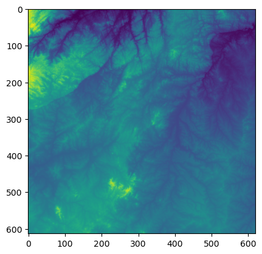

```python
# Apply the previously defined decoding numpy array method
decodedElevation = DecodeNpArrayBase64(jsonData['encodedImage'])
#plot the data to view the elevation geoTiff Data
show(decodedElevation)
```

### Working with the Data:

For demonstration purposes this effort will find contours of a queried area of interest levarging OpenCV

```python
#Import required libraries
import matplotlib.pyplot as plt
#from skimage import measure
import cv2
import imutils
#from PIL import Image
#from matplotlib import cm
from IPython.display import Image
```

```python
def GenerateContoursOfAreaOfINterest(decodedElevation):
    # Define File names for Saving
    GrayScaleFilename = 'test.png'
    contourFileName = 'contoursOf' + GrayScaleFilename

    numpy_image = decodedElevation
    # Convert to Gray scale, This is needed to convert to RBG Gray Scale
    # OpenCV produced errors due to the color format of GeoTiff Generated Numpy Array
    plt.imsave(GrayScaleFilename, numpy_image, cmap='Greys')

    # load the image
    image = cv2.imread(GrayScaleFilename)
    imageT = image.T
    img = imageT

    # Find Canny edges, leveraging Canny from OpenCV
    edged = cv2.Canny(image, 60, 180)

    # Finding Contours
    # Use a copy of the image e.g. edged.copy()
    # since findContours alters the image
    contours, hierarchy = cv2.findContours(edged,
        cv2.RETR_EXTERNAL, cv2.CHAIN_APPROX_NONE)

    # Draw all contours
    # -1 signifies drawing all contours
    cv2.drawContours(image, contours, -1, (0, 255, 0), 3)
    cv2.imwrite(contourFileName, image)
    return GrayScaleFilename, contourFileName
```

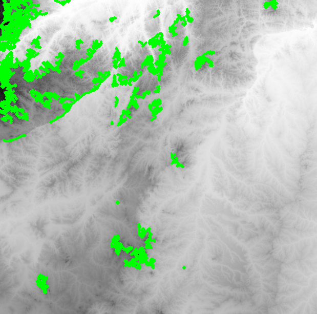

```python
GrayScaleFilename, ContourFileName = GenerateContoursOfAreaOfINterest(decodedElevation)
Image(filename=ContourFileName)
```